# Predictive Pricing Models For Airbnb Milan

Khawaja Hassan

2/9/2022

## Data Cleaning

Our choice provided a cross-sections of Milan listing with more than 16000 observations with last scrapping date of 9th January 2022. However, the data required immense cleaning in terms of extracting amenities into separate columns from their vector form and later clubbing them based on of some meaningful categories. There were around 1000 + separate amenities that is why we aggregated them based on similar characteristics (for example: shampoo, conditioner, bath-gel were collected under the heading of toiletries). We were able to narrow down amenities to 74 clubbed variables. [Function adapted from Viki Meszaros (https://github.com/Viki-Meszaros/CEU-Data-Analysis-3/tree/main/Assignment_1)] After this we prepared our data based on the case we have been provided with, for which we filtered the number of accommodates between 2-6 and took property type which was full apartment (Entire Loft, Entire Serviced Apartment, Entire Apartment, Entire Condominium)

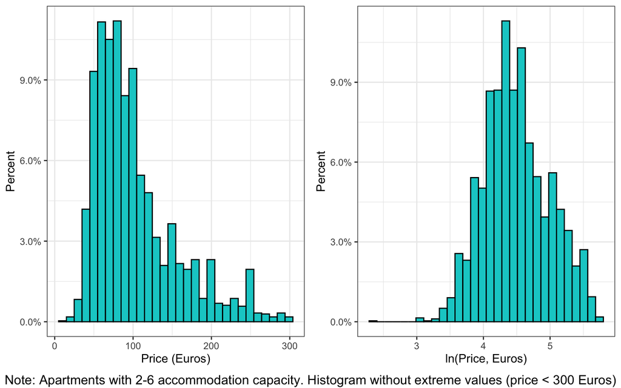

#### Imputation

Moving forward, we had to check what variable can be imputed based on the number of missing values in each of them. Here domain knowledge about the case was essential to come up with some logical assumptions. For number of beds where the value was missing, we took the assumption that it should corresponds 1.5 number of accommodates so for every 3 accommodates there will be at least 2 beds. Whereas, for number of bathrooms we imputed the missing based on the median the value. In this case we did not create any flag variable since the missing observation were below 5 % of the total observation. However, we had certain variable where missing observation was more than 30 % (example: Reviews per month, Review Score Rating) and for which we created flag variable first and then imputed their values with median. Consider the domain knowledge on Airbnb we know how important the reviews rating and the number of rating due to which these variables cannot be left out when constructing predictive pricing models.

#### Explanatory variables

The explanatory variables which were used in our models are as follows:

- *Factor variables*: For each Neighbourhood, type of property, including flag and factorized variable of size variables.
- *Reviews variables*: Review score rating and the number of reviews the apartment gets each month.
- *Host variables*: Created Dummies for host verification and they being a super host or not.
- *Dummies*: Binary variables consisting of all the amenities that are being offered by host.
- *Size variables*: This includes numeric variable like number of beds, baths, accommodates, and minimum nights.

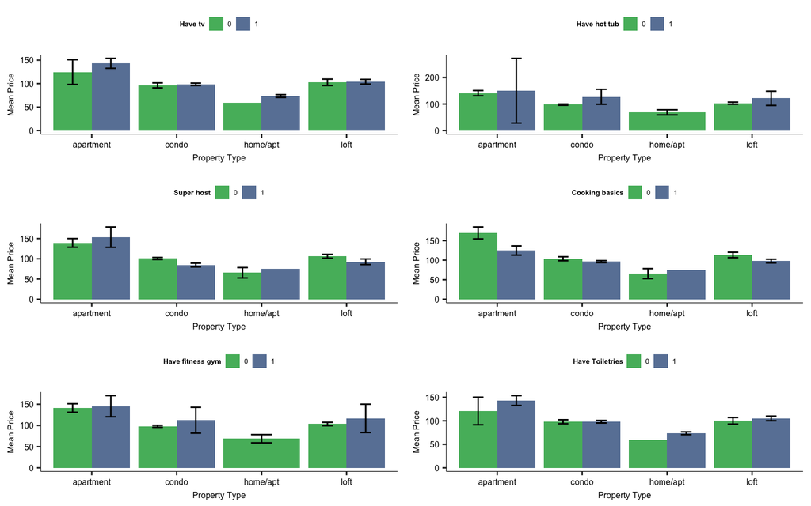

After setting these variables we had to look for the interaction of property type with other variables to check the impact on the mean prices. All those interactions where the mean price was greater than $2-3 those interaction was considered. The reason for this leniency in selecting the interaction was that we first used LASSO on our complex model which included all the variables and interactions. By taking this approach we were able to identify the variable with zero coefficient and disregard them. With the final choice of 126 variables, we move ahead in constructing our price prediction models.

**Cross Validation & Holdout**

To enhance our model performance, we will be dividing our 2500+ remaining observation at random at 20 % as hold set and remaining observation will be used as training set. These training set will then train through 5 test fold cross validation to provide least overfitting coefficients.

# OLS Predictive Models

**Versions of the Airbnb Apartment Price Prediction Models**

| Model | Predictor Variables |
| --- | --- |
| M1 | ~ n_accommodates |
| M2 | ~ n_accommodates+ basic_lev |
| M3 | ~ n_accommodates+ basic_lev + basic_add + reviews + host + dummies |
| M4 | ~ n_accommodates+ basic_lev + basic_add + reviews + host + dummies + interaction |

To start off with our first methodology OLS we run our regression models, based on all the observation in our work set. Using this we calculated the BIC and R-squared for each model respectively. Moreover, to get the Train RMSE and test RMSE we rerun our regression based on our training and test sets via 5-fold cross validations. The result from the model reflect that R-squared is highest in our model 4 where the number Coefficients are 239. However, in comparison if we check result from our BIC and test RMSE we see their value increasing, suggesting this model is overfitting and being penalized. Therefore, the finding of our OLS suggests using Model 3 where not only BIC is minimum but also our test RMSE is lowest.

Comparing Model Fit Model Measures

| Model | Coefficients | R_squared | BIC | Training_RMSE | Test_RMSE |
| --- | --- | --- | --- | --- | --- |
| M1 | 2 | 0.096 | 23731 | 51.1 | 51.1 |
| M2 | 7 | 0.147 | 23641 | 49.7 | 49.7 |
| M3 | 114 | 0.434 | 23555 | 40.4 | 42.6 |
| M4 | 239 | 0.477 | 24343 | 38.9 | 45.2 |
| LASSO | 127 | 0.368 | NA | NA | 42.8 |

# Random Forest

This prediction methodology is based on combining result from many regressions tree, which involves constructing many imperfect trees and averaging the predictions of all the trees to reach the average. This allows for much better predictions than a single model. In our case we used the same holdout and training set and run our model with tuning parameter to allow cross validation to find the tuning parameter value with lowest RMSE in the test set.

Moreover, we will be adopting the same (from Bekes & Kezdi’s RF tuning parameter choices) 3-by-3 for defining mtry tuning parameter and minimum number of observations in each tree split. For our number of variable (mtry) we took the range of 8-12 and for the minimum number of observations (min. nodes) in terminal nodes we have taken (5,10,15). The result from the cross validated test set RMSE values on the combination is shown as following.

Random Forest RMSE by tuning parameters

| nodes | 8 | 10 | 12 |
| --- | --- | --- | --- |
| 5 | 44.7 | 44.0 | 43.8 |
| 10 | 44.8 | 44.3 | 44.0 |
| 15 | 45.0 | 44.4 | 44.1 |

## Variable Importance

To uncover the pattern of association for x-y we created variable importance plot. With the help of this diagnostic tool, we can gain insight about the important variables. The following top 10 important variable plot shows variables which had the largest MSE reduction. In second chart these variables are just grouped based on their factors along with other numeric variables.

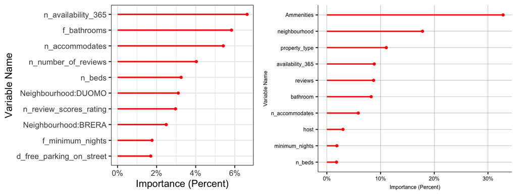

## Partial dependencies

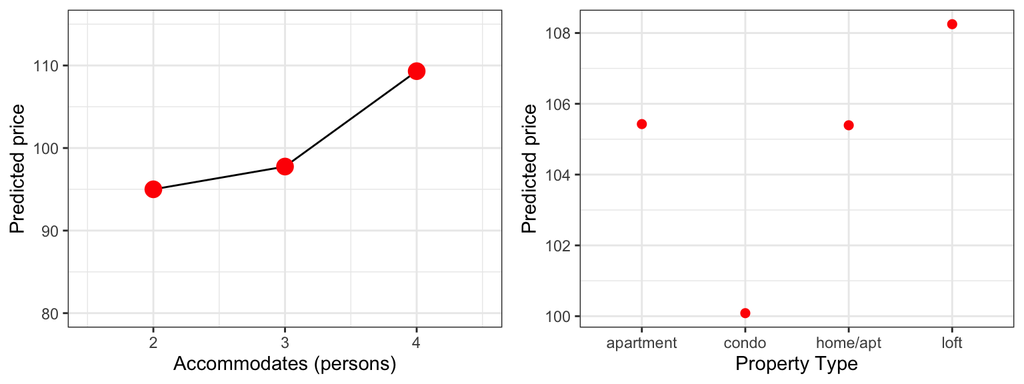

## Sub sample

Performance across sub-sample

| Var.1 | RMSE | Mean.price | RMSE.price |
| --- | --- | --- | --- |
| Apartment size | NA | NA | NA |
| large apt | 47.9 | 115.4 | 0.415 |
| small apt | 34.7 | 89.3 | 0.389 |
| Beds | NA | NA | NA |
| 2 | 44.5 | 105.1 | 0.424 |
| 3 | 48.0 | 113.8 | 0.421 |
| 4 | 49.7 | 122.1 | 0.407 |
| 5 | 63.3 | 104.8 | 0.604 |
| 6 | 35.8 | 158.8 | 0.225 |
| Property Type | NA | NA | NA |
| apartment | 40.5 | 150.4 | 0.269 |
| condo | 36.3 | 95.7 | 0.379 |
| loft | 52.9 | 103.2 | 0.512 |

## Conclusion

Horse Race of Models CV RSME

|  | CV RMSE |
| --- | --- |
| OLS | 42.6 |
| CART | 46.5 |
| Random forest 1: Tuning provided | 43.8 |
| Random forest 2: Auto Tuning | 42.5 |